# Road transport pricing elasticities

*Principal Economics October 2024*

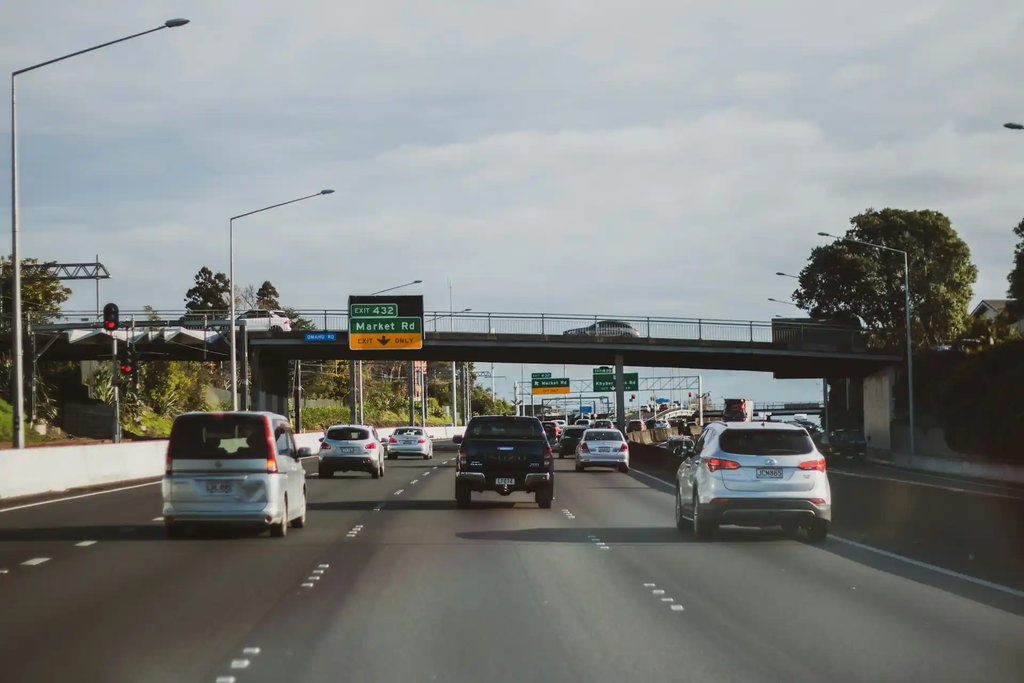

#### http://www.principaleconomics.com

Road transport pricing elasticities

# Executive summary

This knowledge base provides technical discussions of the available estimates of elasticities.

In developing carbon and GHG reduction polices, it is important to bear in mind that for any given journey an individual will take account of a range of factors other than price in deciding which mode of transport to use. These include:

- the scheduled or expected journey time,
- the reliability of the mode in question,
- relative levels of comfort and convenience, and
- flexibility of travel arrangements.

Given this important role for elasticities, in this knowledge base we investigate the available local and international literature. We complement the available information with our own investigation of elasticities across the three large New Zealand regions and different socioeconomic groups. The outputs will be used to inform possible variation in elasticities (ie, response to changes in price of LV and PT) required for the analysis of transport and equity impacts of various transport initiatives.

The summary table can be further disaggregated for different features of trips, such as peak and off-peak. We provide further information on the disaggregation in this database. The outcomes provide more information on the likelihood of effectiveness of a pricing policy and the magnitude of impacts – which provide important information about the necessary and sufficient conditions for achieving policy targets.

#### Table E.1 Summary of implied elasticity values for transport demand analysis

| Change | Measure | Database |
| --- | --- | --- |
| LV Generalised Costs | LV Trips | -0.3 |
| (Range 0% to +400%) | LV VKT | -0.4 |
| LV Fuel Costs | LV Trips | -0.2 |
| (Range +0% to +100%) | LV VKT | 2 yr = -0.3 (NZ) |
|  | PT Trips | 0.07-0.40 |
|  | Cycle Trips | n/a |
| PT Fares | PT Trips | -0.35 [-0.25/-0.50] |
| (Range +100% to -90%) | LV VKT |  |
| PT Frequency | PT Trips | +0.4 [+0.30/+0.50] |
| (Range +100% to -90%) | LV VKT |  |
| PT IVT | PT Trips | -0.40 [-0.30/-0.50] |
| (Range +100% to -90%) | LV VKT |  |
| Cycle Generalised Costs | Cycle Trips | n/a |
| (Range 0% to -50%) | LV VKT | n/a |
| Walk Generalised Costs | Walk Trips | n/a |
| (Range -10% to +10%) | LV VKT | n/a |

Source: Principal Economics

# 1 Database of elasticities

In this section, we first provide a description of the database we collected from the existing literature on travel demand, road pricing and parking elasticities sourced primarily from New Zealand, Australia and complemented with most relevant information from other jurisdictions.

## 1.1 Database - travel demand elasticities

The primary focus of our review of the available elasticities is on New Zealand and Australia data.[^1] The behavioural responses (in terms of elasticities) have been similar across the two countries (even though absolute cost values may differ, reflecting different income profiles across countries and regions). This is also because Australia has a number of cities that are in broadly similar population range to the three regions’ range, developed over a generally similar time period, and would be expected to have generally similar trip rates, mode shares and travel patterns. In some cases, we further consider available information from other countries, including the UK, other North-West Europe countries (particularly Sweden, Norway, Netherlands), USA and Canada.

We first investigate PT changes (affecting PT and alternative mode demand), then road user cost and conditions changes (affecting principally car/LV and alternative mode demand, including PT).

### 1.1.1 Elasticity responses over time

Market responses to changes in public transport system are not instantaneous: while the greatest response is generally in the first few months following the change, responses may continue to grow over a much longer period, but at a diminishing rate. The literature typically categorises responses into short-, medium- and long- run, but is not consistent in the definition of the length of these periods.

We have generally adopted the period definitions as used in each literature source. Where possible, we have adopted the category definitions favoured by Fearnley and Bekken (2005), ie short-term relates to the response within one year of the change, medium term to the response within 3 years and long-term to the response within 7 years of the change. As commented by Fearnley & Bekken (2005), “Assuming anything about effects longer than that is probably spurious and only of academic interest.”

### 1.1.2 Elasticity responses over time

#### 1.1.2.1 Overview

This section covers two main aspects:

- The major part (Sections 1.1.2 - 1.1.4) applies an approach based on demand elasticity methods and estimates to assess the impacts of changes to PT services (principally in terms of fare levels and service levels) on the usage (patronage) of these services, having regard to the timescale over which these impacts will arise.
- The following part (Section 1.1.5) then addresses the cross-modal (modal switching) impacts that are expected to occur consequential on the changes in the PT service characteristics.

The section draws heavily on work undertaken by Douglas Economics and Ian Wallis Associates (2013) as part of the Australian Federal Government’s ATAP Guidelines for Public Transport.[^2] While that work has an Australian focus, it also includes some New Zealand evidence. Based on these studies and our expert advice, in terms of market responses to PT system improvements, the relevant elasticities in the two countries are indistinguishable. Given this, while our estimates given in this section are largely based on Australian evidence, there may be applied with some confidence to the New Zealand transport market.

#### 1.1.2.2 Direct elasticities of demand – primary components

Table 1.1 presents a set of short-run default elasticity estimates for public transport (with a focus on bus services) demand with respect to fares, service levels and in-vehicle time.

#### Table 1.1 Short-run component elasticity estimates

| Attribute | Best estimate (default) values Overall | Best estimate (default) values Peak | Typical ranges Off-peak | Typical ranges (All periods) |
| --- | --- | --- | --- | --- |
| Fares | -0.35 | -0.25 | -0.5 | -0.2 to -0.6 |
| Service levels | 0.40 | 0.30 | 0.5 | +0.2 to +0.7 |
| In-vehicle time | -0.40 | -0.30 | -0.5 | -0.1 to -0.7 |

Source: Australian Transport Assessment and Planning Guidelines: M1 Public Transport (2021)

*Note: Best estimates reflect medium frequency (20-30 minutes headway). As noted in the text, service level elasticities may be higher than indicated in this range in evenings and weekends when frequencies are relatively low.*

The following points should be noted in relation to Table 1.1:

Table 1.2 provides further evidence of how the short-run elasticity estimates vary across a range of market situations and trip characteristics. The following points should be noted in relation to the evidence in Table 1.2:

- Strong systematic variations in elasticities exist between trip purposes and time periods (the two factors being strongly correlated) for all three variables. Weekday off-peak elasticities are around twice peak period elasticities and weekend elasticities are generally higher than weekday off-peak values.
- Elasticities vary in a complex way with trip distance: this can be explained in part by the availability of substitutes, with high elasticities for short trips having the alternative of walking; and in part by the importance of the component measure in the total trip generalised cost.
- Elasticities vary with city size (which acts as a proxy for the level of PT services), although the fare effect and the service level effect appear to be opposite. However, there is limited data relating to this issue.
- Both fare elasticity and service elasticity vary significantly, although rather less than proportionately with the magnitude of the base fare or headway. This is particularly significant regarding service headways: a typical service elasticity would be around 0.2 at short headways (better than every 10 minutes) increasing to around 0.5 to 0.6 or more at longer headways (hourly or longer). These variations are broadly consistent with a constant generalised cost elasticity formulation.
- Most studies show no significant difference in elasticities between fare increases or decreases, or large or small fare changes. Similarly, the limited evidence on service elasticities suggests no significant differences in elasticities between service increases and decreases, or between large and small changes.

#### Table 1.2 Summary of evidence on component elasticities for key variables

| Aspect | Fares | Service levels | In-vehicle time |
| --- | --- | --- | --- |
| Trip purpose/ time period | Off-peak/non-work typically twice peak/ work; weekend most elastic | Off-peak/non-work typically about twice peak/work; weekend most elastic (may be partly due to frequency differences) | Inconclusive regarding relative elasticities, although most evidence is that off-peak is more elastic than peak |
| Mode | Bus elasticities typically somewhat greater than rail (but largely reflects shorter bus trip lengths) | No evidence of significant differences (apart from variations with headway) | Bus elasticities typically lower than rail (reflecting longer trips by rail with in-vehicle time a greater proportion of generalised costs) |
| Trip distance | Highest at very short distances (walk alternative), lowest at short/medium distances, some increase and then decrease for longest distances (beyond urban area) | Highest at short distances (walk alternative) | Limited evidence - longest trips more elastic than short/medium distance trips |
| City size | Lower in larger cities (over 1 million population) - US evidence | Higher in larger cities - EU evidence | No evidence |
| Base level of variable | Elasticities increase with base fare level, but less than proportionately | Elasticities increase with headways, but less than proportionately | No firm evidence, although expect elasticities to increase with proportion of total trip (generalised costs) spent in- vehicle |
| Magnitude of change | No significant variation in elasticities with magnitude of change (most studies) | No significant variation in elasticities with magnitude of change (most studies) | No evidence |
| Direction of change | No significant differences for fare increases and decreases (most studies) | Evidence does not indicate significant differences between service level increases and decreases | No evidence |

Source: Australian Transport Assessment and Planning Guidelines: M1 Public Transport (2021)

### 1.1.3 Factors affecting bus service level elasticities

As discussed, the magnitude of elasticities have significant implications for the identified impacts of policies. Therefore, it is important to understand the underlying reasons for variation in elasticities. This section takes a closer look at urban bus service elasticities, based largely on earlier work undertaken by Ian Wallis Associates (2013). That work assessed evidence on service elasticities for three centres in New Zealand (across Auckland, Dunedin, Hamilton regions) and four centres in Australia (Perth, Brisbane, Adelaide, Melbourne). Reflecting the extent of data available in each centre, the elasticity-related analyses focused primarily on the last three of these centres, with most data being available for Melbourne.

The results summarised in this section all relate to service elasticities derived for the fourth quarter (ie months 9-12) following service increases.

#### 1. Elasticity estimates by time period:

- Elasticity estimates vary considerably between weekday time periods (peaks, interpeak, evening) and between weekdays and weekends. Within weekdays, elasticities are lowest in the peak periods (c0.30), somewhat higher in the interpeak (c0.45) and higher again the evenings (typically around 0.6). Overall, weekend elasticities (around 0.6 -0.7) are significantly higher than weekday elasticities (average 0.4 – 0.5).

#### 2. Differences between cities and between routes:

- Overall, the elasticity estimates derived for a given time period showed a strong consistency between cities and different routes within a given city. For example, the mean elasticities for weekend service levels averaged 0.64 for Melbourne (SmartBus services – 4 cases), 0.61 for Adelaide (7 cases) and 0.73 for Brisbane (11 cases).[^3]

#### 3. Differences by initial service frequency:

- It is often assumed that elasticities for a low-frequency service will be greater than for a high-frequency service, eg the proportionate change in demand for a service change from two hourly to hourly would be greater than the proportionate change from a service every 10 minutes to every five minutes.
- This proposition was not supported by our analysis of elasticity against initial frequency for the services examined (Adelaide, Brisbane, Melbourne), although the results were not conclusive in statistical term. Based on the evidence known to us, the usual assumption of constant elasticity values has not been rejected.
- However, an analysis comparing the elasticity against the service frequency for different time periods showed an apparently-strong relationship between these two variables (Figure 1.1). We hypothesise that this apparent relationship reflects the different market characteristics at different time periods rather than any inherent differences in the elasticity estimates.

#### 4. Effects of extent of service changes:

Another question of interest was whether elasticity values would vary according to the extent of any service changes:

- One view is that passengers would hardly notice a small service change, but would respond more (proportionately) to a large change.
- The opposite view is that large changes would (proportionately) result in diminishing returns and hence lower elasticity values.

Wallis (2013) examined how examined how elasticity estimates varied with the percentage change in service frequency (bus trips per hour) and concluded that no significant relationship was apparent between the elasticity and the extent of the service change, ie the constant elasticity assumption assessments had not been disproved.[^4]

#### 5. Effects of direction of service change:

The question addressed here is whether service elasticities are ‘symmetric’ with regard to service increases and decreases; ie, would the elasticity values for service increases and decreases be the same.[^5]

#### Figure 1.1 Melbourne (MEL) SmartBus elasticity vs service frequency

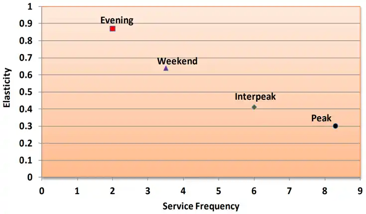

##### Source: Wallis (2013, p. 64)

### 1.1.4 Valuation of ‘travel convenience’ factors: travel time multipliers

Through public transport pricing studies undertaken in New Zealand (Douglas, 2015) and Australia (ATAP Guidelines M1: PT Parameter Values), a set of guideline travel time (IVT) multipliers has been derived covering: walk access/egress, service interval (service frequency), travel time displacement (not travelling at the most desirable time), interchange (transfer penalties and connection time), onboard crowding and reliability (Douglas, 2015, 2021).[^6]

The generalised time measure was converted into generalised cost by multiplying by the average (behavioural) value of time [^7] obtained for seated time in uncrowded conditions on an average quality vehicle. Table 1.3 presents the resulting guideline travel time multipliers (all expressed relative to seated time in uncrowded conditions on an average quality vehicle). The table also includes a column showing multiplier values estimated by an OECD study by Wardman (2014). Accordingly, the OECD and the NZ/Australian study values are reasonably close.

We are aware that there are some differences between the travel time multipliers used in the current transport models in the three New Zealand metropolitan areas and those specified in Table 1.3. These differences have not been investigated in detail at this stage.

#### Table 1.3 Summary of travel time multipliers

| Attribute | Australian/NZ Review |  |  |  |  |  | OECD Review | Notes |  |  |
| --- | --- | --- | --- | --- | --- | --- | --- | --- | --- | --- |
| Service Interval | 0.7 |  |  |  |  |  | 0.5 - 0.8 | The SI/IVT value of 0.7 allowed for a upward trend in valuation over the review period and compares with an average of 0.64 based on 115 obs. A curvilinear function was estimated which declined from 0… |  |  |
| SI (mins/depts) | 5 | 10 | 20 | 30 | 40 | 60 | na |  |  |  |
| SI/IVT Valuation | 0.9 | 0.8 | 0.7 | 0.5 | 0.4 | 0.4 |  |  |  |  |
| Travel Time Displacement | Early |  | Late |  | Average |  |  |  | Average | The cost of not being able to travel at the desired time. There were only two Sydney studies giving early displacement at 0.5, late displacement at 0.75 and average displacement at 0.6. The recommende… |
|  | 0.33 |  | 0.5 |  | 0.42 |  | 0.4 - 0.6 |  |  |  |
| Wait Time | 1.4 |  |  |  |  |  | 1.75 - 2 |  | Valuation based on decomposition of SI valuation. |  |
| Net Transfer Penalty (mins of IVT) | Same Mode Transfer |  |  | Different Mode Transfer |  |  | Penalty | 21 studies provided 75 observations from which the average net transfer penalty (excluding time spent at the transfer) averaged 6 minutes for a same mode transfer e.g. bus to bus or train to train. Fo… |  |  |
|  | 6 |  |  | 10 |  |  | 5 - 15 (Gross included transfer time) |  |  |  |
| Transfer Connection Time | 1.5 |  |  |  |  |  |  |  | Time at the transfer (largely waiting time) was valued at 1.5 x IVT based on 25 observations. Valuation likely to vary with walk/wait & conditions (seating/shelter & crowding). |  |
| Crowding Multipliers | Crowded Seat |  | Standing |  | Crush Standing |  | Standing | 14 studies (30 obs) estimated crowding multipliers. Crowded seating time was valued a fifth higher than uncrowded seating. Standing multiplied the time cost by 1.65 with crush standing more than doubl… |  |  |
|  | 1.2 |  | 1.65 |  | 2.1 |  | 1.5 - 2 |  |  |  |
| Reliability (Average Mean Lateness) | At Stop Departure |  | On-vehicle Arrival |  | Average |  | Lateness |  | 10 studies (15 obs) measured reliability as Average Mean Lateness (AML) calculated as the proportion of services late multiplied by the number of minutes late. Departure AML at stops was valued higher… |  |
|  | 5.9 |  | 2.8 |  | 4.1 |  | 3 - 5 |  |  |  |
| Access/Egress: Walk | 1.5 |  |  |  |  |  | 1.75 - 2 | 21 studies (19 SP, 2 RP) gave av. multiplier of 1.32 however 2 studies of actual behaviour (Sydney Travel Model calibration) gave higher value of 1.5 and this value is recommended. Valuation will incr… |  |  |

##### Source: Australian Transport Assessment and Planning (ATAP) Guidelines – M1 Public Transport: Parameter Values Technical Report (Douglas, 2021)

#### 1.1.4.1 Valuation of vehicle quality and stop/station quality

Market surveys using a rating-based approach been undertaken to develop passenger valuations for both vehicle/on-board quality aspects and stop/station aspects. This market research involved three large-scale surveys undertaken in NZ (Auckland, Christchurch, Wellington), NSW and Victoria in 2012-14. In total, the vehicle quality surveys resulted in some 26,000 completed questionnaires and the stop/station surveys some 29,000 responses.

The three studies use the same hybrid approach involving stated preference and rating questionnaires and transforming their results into passenger willingness-to-pay (per trip and/or per km travelled) for higher quality relative to lower quality vehicle and stop features.

The vehicle quality surveys estimated user (perceived) benefits of up to about 4 IVT minutes per trip (eg for Wellington, for the new Matangi units relative to the old Ganz Mavag units). For rail stations, a major station upgrade would result in a perceived benefit of up to about 4 IVT per person trip relative to a station which had not been substantially refurbished for many years.

Mode Specific Constants (MSCs) measure the residual difference in modal quality after differences in travel convenience (notably access/egress time, in-vehicle time, service frequency, transfer, crowding, reliability and fare) have been allowed for. They are often used in multi-modal studies such as forecasting the patronage for new services.

### 1.1.5 Modal switching effects: diversion factors

When public transport services are improved, the additional patronage observed on the public transport system originates from a variety of prior modes and other sources, principally:

- Previous car use (as driver or passenger) for the trip in question
- Previous active mode use (as pedestrian or cyclist) for the trip in question
- Generated trips (ie the same or a similar trip would not have been made at all without the public transport improvements).

Conversely, when PT services become less attractive for any reason (eg reduced frequencies, higher fares, poorer reliability), a proportion of PT passengers will make other arrangements for their trips, using alternative modes or perhaps travelling less frequently.

A significant amount of evidence is available on the prior modes of additional passengers attracted to an improved PT service, as summarised in the following sections - although this literature is less extensive than that on the corresponding direct elasticities (eg refer Balcombe et al. (2004), Wallis (2004)). Much less evidence is available on the alternative modes of passengers ‘lost’ when the service deteriorates.

Two alternative approaches are often used to estimate cross-modal effects, involving the application of (i) cross-elasticity relationships; or (ii) diversion factors (the generally-preferred method).

**Cross-elasticity approach:**

This approach derives cross-modal elasticity estimates from experience elsewhere in broadly comparable situations, and then applies these to the level of change (%) in the public transport service features (eg fare levels) to estimate the extent of change (%) in the use of the previous mode. For example:

- Assume public transport service levels are increased by 30%
- The cross-elasticity of car driver demand with respect to public transport service levels is estimated, from experience elsewhere, at -0.10.
- Hence the service level increase will change car (driver) use in the area/corridor in question by 30% * -0.10 = -3%, (ie, a 3% reduction).

While the evidence is that direct elasticities (for a given market segment) are generally quite consistent across different countries and cities, this is not the case for cross-elasticities: cross-elasticities are found to be sensitive to the previous mode share ratio (ie, public transport mode share/alternative mode share), and are therefore not readily transferable unless these initial mode shares are explicitly taken into account when considering the cross-elasticity evidence.[^8] Given this, the remainder of this section focuses on the ‘diversion factor’ approach as the preferred method.

**‘Diversion factor’ approach**

The ‘diversion factor’ resulting from a public transport initiative is the proportion of the ‘new’ public transport passengers who previously made the trip in question by the specified mode (eg, as car drivers). In this context, the ‘new’ public transport passengers are those who did not previously use public transport for their trip.

Table 1.4 provides evidence from a range of Australian and international sources of the patronage impacts of major urban public transport initiatives in terms of the previous travel modes of their users. For each initiative, it shows the proportionate breakdown according to previous mode of travel for:

- Total patronage following the initiative – unbracketed figures, and
- ‘New’ public transport passengers only (ie those who did not previously use public transport for the trip). These proportions (shown in brackets) represent the diversion rates from each previous mode.

These results show a good degree of consistency across the range of schemes of different types and in different countries. One finding is that, on average, some two-thirds of all users of major public transport initiatives had previously used public transport for their trip. Of the remaining (approximately one-third) users of the new initiative, typically 40% 50% would otherwise have made their trip by car, with the majority of these (circa 35% to 40% of new public transport users) making the trip as car drivers.

This finding applies to the various schemes (involving major infrastructure investments) included in the table. In addition, it should be noted that:

- For public transport initiatives particularly oriented to attracting motorists, use of the higher car driver diversion rates is appropriate. These include initiatives such as park & ride facilities and express bus services, each with diversion rates from car drivers of over 50% and in some cases as high as 70% to 80%.
- For public transport initiatives with a more ‘social’ focus, use of the lower car driver diversion rates is appropriate. These include off-peak fare schemes and suburban bus route enhancements. For these schemes, the diversion rates from car driver may be as low as 20% to 30%.

The mapping of Table 1.4 against the terms ‘diverted’ and ‘generated’ trips is as follows:

- The ‘did not travel’ column represents newly generated trips
- The ‘existing PT users’ column represents trips diverted from one public transport mode to another
- The other columns represent trips diverted to public transport from other modes.

#### Table 1.4 Previous mode of travel by public transport users (and diversion rates) after the implementation of major public transport projects %

| Initiative | Proportions of market by previous modes Car driver | Proportions of market by previous modes Car passenger | Proportions of market by previous modes Did not travel | Proportions of market by previous modes Walk/ Cycle | Proportions of market by previous modes Other | Proportions of market by previous modes Total | Existing PT users | Overall total |  |  |  |  |  |  |  |  |
| --- | --- | --- | --- | --- | --- | --- | --- | --- | --- | --- | --- | --- | --- | --- | --- | --- |
| Australian/NZ schemes |  |  |  |  |  |  |  |  |  |  |  |  |  |  |  |  |
| Adelaide O-Bahn | 13 | 6 | 9 | * | 4 | 33 |  |  | 67 | 100 |  |  |  |  |  |  |
|  | -41 |  | -27 |  | -14 |  |  |  |  |  |  |  |  |  |  |  |
| Melbourne SmartBus | 21 |  | 25 |  | 19 |  | 32 | 100 |  |  |  |  |  |  |  |  |
|  | -31 |  | -37 | -6 | -28 | -100 |  |  |  |  |  |  |  |  |  |  |
| Auckland Northern Busway (Express service) | 32 |  |  | 1 |  |  |  |  |  |  | 56 | 100 |  |  |  |  |
|  | -72 |  |  | -2 |  |  |  |  |  |  |  |  |  |  |  |  |
| Perth Northern Suburbs Railway | 23 |  |  |  |  |  | 65 | 100 |  |  |  |  |  |  |  |  |
|  | -66 |  | -29 |  | -3 |  |  |  |  |  |  |  |  |  |  |  |
| Bundoora (Melb) Tram extension | * |  | * |  | 5 |  |  |  | 68 | 100 |  |  |  |  |  |  |
|  | * |  | * |  | -15 |  |  |  |  |  |  |  |  |  |  |  |
| UK Heavy/Light Rail Schemes |  |  |  |  |  |  |  |  |  |  |  |  |  |  |  |  |
| Birmingham (cross- City rail link) | 11 |  | 26 |  | * | 37 | 63 | 100 |  |  |  |  |  |  |  |  |
|  | -30 |  | -70 |  | * | -100 |  |  |  |  |  |  |  |  |  |  |
| Merseyside Rail (link/loop project) | 20 |  | 24 |  | * | 44 |  |  |  |  |  |  | 56 | 100 |  |  |
|  | -45 |  | -55 |  | * | -100 |  |  |  |  |  |  |  |  |  |  |
| West Yorkshire (new rail stations) | 16 |  | 13 |  | 2 | 31 | 69 | 100 |  |  |  |  |  |  |  |  |
|  | -52 |  | -42 |  | -6 | -100 |  |  |  |  |  |  |  |  |  |  |
| Manchester MetroLink | 14 |  | 15 |  | * | 29 |  |  | 71 | 100 |  |  |  |  |  |  |
|  | -48 |  | -52 |  | * | -100 |  |  |  |  |  |  |  |  |  |  |
| Glasgow Rail (cross- city rail link) | 15 |  | 15 |  | * | 30 | 70 | 100 |  |  |  |  |  |  |  |  |
|  | -50 |  | -50 |  | * | -100 |  |  |  |  |  |  |  |  |  |  |
| London Underground | 20 |  | 19 |  | * | 39 |  |  |  |  | 61 | 100 |  |  |  |  |
|  | -51 |  | -49 |  | * | -100 |  |  |  |  |  |  |  |  |  |  |
| UK Busway Scheme |  |  |  |  |  |  |  |  |  |  |  |  |  |  |  |  |
| Cambridgeshire Guided Busway | 20 | 11 | * | 3 | 2 | 36 | 64 | 100 |  |  |  |  |  |  |  |  |
|  | -57 | -30 | * | -8 | -5 | -100 |  |  |  |  |  |  |  |  |  |  |
| European Light Rail Scheme |  |  |  |  |  |  |  |  |  |  |  |  |  |  |  |  |
| Grenoble LRT | 5 |  | 4 |  | 3 | 12 |  |  | 88 | 100 |  |  |  |  |  |  |
|  | -42 |  | -33 |  | -25 | -100 |  |  |  |  |  |  |  |  |  |  |
| Nantes LRT | 10 |  | 16 |  | 7 | 33 | 67 | 100 |  |  |  |  |  |  |  |  |
|  | -30 |  | -48 |  | -21 | -100 |  |  |  |  |  |  |  |  |  |  |
| Nieuwegein LRT | 8 |  | 10 |  | 5 | 23 |  |  |  |  |  |  |  |  | 77 | 100 |
|  | -35 |  | -43 |  | -21 | -100 |  |  |  |  |  |  |  |  |  |  |

Note 1: Unbracketed figures show the proportions of passengers using the new service broken down by their previous mode of travel. Figures in brackets show the proportions of new public transport passengers (resulting from the initiative) broken down by their previous mode of travel (ie the relevant diversion rate).

Note 2: * means not covered in this survey

##### Source: Australian Transport Assessment and Planning (ATAP) Guidelines – M1 Public Transport: Parameter Values Technical Report (Douglas, 2021)

### 1.1.6 Generalised cost elasticity of demand

The impacts on PT travel demand resulting from changes in journey characteristics (eg walk time, waiting time, fare etc) are sensibly independent and additive. In this regard, the concepts of ‘generalised journey time’ or ‘generalised cost’ are very useful for analysis purposes:

- The ‘generalised time’ (GT) is the sum of all journey time components (appropriately weighted) plus all ‘out-of-pocket’ journey costs (principally fares for PT travel but may involve other cost components). GT is usually expressed in terms of equivalent in-vehicle minutes, with the monetary component being converted to IVT units based on behavioural values of time for each part of the trip (eg may involve differing unit values for walking time and for in-vehicle time).
- The ‘generalised journey time’ (GJT) comprises only the time component of GT, ie omitting any monetary costs.
- The ‘generalised cost’ (GC) is the similar sum to the GT but expressed in monetary ($) rather than time terms. (The ratio of GC to GT represents the behavioural value of IVT, in dollars/hour or similar units.)

Given that most components of PT journeys relate to a (weighted) behavioural measure of time, there are merits in using GJT (rather than GC) for analysis purposes, but this makes no difference to the results of any analyses. We therefore generally use GJT for providing some information, with all journey time and cost components expressed in terms of equivalent in-vehicle minutes.

The generalised time (or the generalised cost) definition may be expanded to include other features of (particularly) PT trips which influence people’s travel behaviour (in terms of their choice of mode or service and/or their willingness-to-pay). These features are often referred to as travel convenience features, as discussed further in the next section.

Based on the Douglas (2021), the weight of Australian and international evidence indicates typical elasticities of urban public transport demand with respect to total generalised costs (or generalised time) as:

- Short-run (within 12 months of change) – peak -1.0; off-peak -1.5 to -2.0.
- Long-run (7–10 years after change) – generally indicated in the economic literature as being approximately twice the short-run values; however, the Australian evidence on ramp-up profiles indicates that this factor applies only to major infrastructure schemes, while the speed of ramp-up is much greater for smaller public transport schemes and hence the long-run: short run ratio much lower.

Apart from the differences between peak and off-peak values, the weight of evidence suggests generalised cost elasticities are reasonably stable over a wide range of urban public transport situations across developed countries. However, it should be noted that:

- Weekend elasticities are generally higher than weekday (off-peak) elasticities
- Elasticities tend to be higher than average for short trips, where walking is a competitive alternative, and lower than average for medium and long-distance trips
- There is no evidence of systematic differences in generalised cost elasticities between different urban public transport modes, apart from the distance effect.

### 1.1.7 Impacts of fuel price changes on traffic volumes and fuel consumption

In this section we provide a review of the literature available in New Zealand, Australia and other countries on the impact of fuel price on mode choice.

#### 1.1.7.1 New Zealand evidence

Table 1.5 summarises previous econometric studies on petrol consumption elasticities in New Zealand.

#### Table 1.5 Previous New Zealand studies on petrol consumption elasticities.

| Reference for study | Short-Run | Long-Run | Estimation Method |
| --- | --- | --- | --- |
| Barns (2002) | -0.20 | -0.07 | Cointegration model |
| MED (2000) | -0.07 | -0.19 | Partial adjustment model |
| Ministry of Commerce (1991) | -0.03 | -0.07 | Not established |
| Waikato University (1982) | -0.13 | -0.16 | Not established |
| Hughes (1980) | -0.11 | -0.14 | Not established |

Most short-run values are around -0.10 (range -0.03 to -0.13), and long-run values are around -0.15 (range -0.07 to -0.19). The exception is Barns (2002), who estimated a relatively high short-run elasticity (-0.20) but a lower long-run figure. While her research methods appear robust, her relative long-run v short-run findings are contrary to almost all other evidence internationally.

Note that the New Zealand estimates derived in Kennedy & Wallis (2007) (around -0.15 in the short run and -0.20 in the medium run) are within, but towards the high end of the range found from these previous New Zealand studies.

#### 1.1.7.2 Australian evidence

Table 1.6 summarises econometric studies of petrol consumption elasticities in Australia.

- One of the most robust and transparent studies is that by Sterner et al. (1992). This fitted a partial adjustment model to Australian data from 1960 to 1985 and employed valid tests for autocorrelation. It also fitted a number of alternative models which all produced long-run estimates in the -0.1 to -0.2 range.
- These long-run estimates are supported by research by Samimi (1995), who estimated a long-run elasticity of -0.13 from data for the period 1980-1993. (Samimi’s research covered both petrol and diesel, so the petrol price elasticity would be expected to be rather larger than this estimate.)
- Sterner et al’s short-run estimate is supported by Harding’s survey (2001). His elasticity estimate of -0.05 is based on household consumption only, and may underestimate the total impact, but is still more robust than many time-series estimates

#### Table 1.6 Previous Australian studies on petrol consumption elasticities.

| **Study reference** | **Short-run** | **Long-run** | **Not stated or** **Not established** | **Estimation Model/ Method**[^9] |
| --- | --- | --- | --- | --- |
| Brain & Schuyers (1981) | -0.11 | -0.22 |  | Not established |
| Donnelly (1984) | -0.12 | -0.67 |  | Not established |
| Filmer & Mannion (1979) | -0.03 | -0.07 |  | Not established |
| Harding (2001) | -0.05 | n/a |  | Survey Analysis |
| Hensher & Young (1991) |  |  | -0.25 (direct estimate) | Static Model |
| -0.66 (indirect calculations) |  |  |  |  |
| Samimi (1995) | -0.02 | -0.13 |  | Cointegration Model |
| Schou & Johnson (1979) |  |  | -0.02 to -0.08 | Static Models: OLS and Cooley-Prescott |
| Sterner, Dahl & Franzen (1992). | -0.05 | -0.18 |  | Partial Adjustment Model but other models also fitted |

- The long-run values centre around -0.15 (four of five values are in the -0.07 to -0.22 range); this is again very similar to the range for New Zealand (the exception is Donnelly’s estimate of -0.67), but substantially lower than the conclusion in Luk & Hepburn’s (1993) review.

From this evidence, nothing indicates any significant differences between Australian and New Zealand consumption elasticities.

#### 1.1.7.3 International evidence

Sterner et al. (1992) produced estimates of short-run and long-run elasticities for 21 OECD countries. These estimates are useful for comparisons across countries because they were produced using the same model (a partial adjustment model) and with data covering the same period (1960-1985). Their estimates aggregated by countries or regions of particular interest are summarised in Table 1.7.

### Table 1.7 International studies for petrol consumption elasticities.

| Country/region | Short-run | Long-run |
| --- | --- | --- |
| Australia | -0.05 | -0.18 |
| US | -0.18 | -1.00 |
| Canada | -0.25 | -1.07 |
| Europe |  |  |
| - average | -0.28 | -0.88 |
| - range | -0.05 to -0.57 | -0.18 to -2.29 |
| - UK | -0.11 | -0.45 |

##### Source: Sterner et al. (1992)

Notable features of these results include:

- Australia shows the lowest elasticities of all countries analysed, in both the short run and long run (New Zealand was not included in this study).
- The US and Canadian elasticities are broadly similar to each other, and substantially higher than the Australian figures, especially in the long run.
- The European average figures are somewhat higher than the US/Canadian figures for the short run, and somewhat lower in the long run.
- The European averages encompass a considerable range across the different countries: UK is near the bottom of this range, with elasticities lying between the Australian and US levels Goodwin et al. (2004), in their review of UK studies, also found that UK consumption elasticities were relatively low, with a short-run best estimate of about 0.09 and a long-run estimate of about -0.23.

#### 1.1.7.4 Comparisons and conclusions

The Sterner et al. (1992) data was manipulated by the authors of the Kennedy and Wallis (2007) report so that comparisons of consumption elasticity estimates with petrol prices in different countries could be made. The comparisons for the short-run elasticity are summarised in Figure 1.2, which shows a relationship that is almost linear through the origin, ie the short-run elasticity is almost directly proportional to the price level. This implies that the percentage consumption change is more closely related to the absolute price change rather than the percentage price change. (A similar, but weaker, relationship appears to exist for the long-run elasticity estimates produced by Sterner et al. (1992)) The absolute price differences between different countries may thus explain a substantial proportion of the elasticity differences between countries.

#### Figure 1.2 Relationship of short-run petrol consumption elasticity and price across different countries

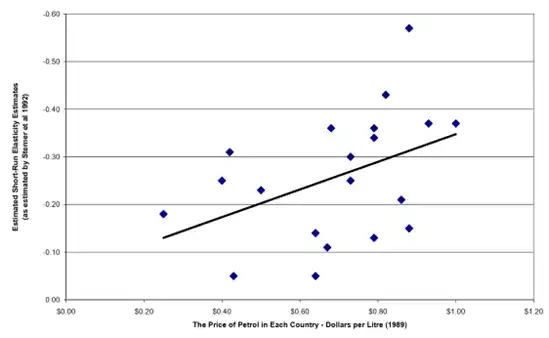

##### Source: Sterner et al. (1992)

Interpretation of the range of international results in terms of underlying differences in petrol consumption elasticities between countries is far from straightforward. The available literature suggests a variation between -0.1 and -0.4 for most countries at different price levels. The LV trips’ short-run elasticity is approximately -0.2 and the LV VKT elasticities is -0.28.

### 1.1.8 Traffic volume elasticities

#### 1.1.8.1 **New Zealand evidence**

The Kennedy and Wallis (2007) study appears to be the first study in New Zealand to attempt estimates of traffic volume elasticities with respect to petrol prices: no previous studies have been identified. Most likely, the absence of previous studies into traffic volume elasticities reflects the lack of data available in earlier years.

#### 1.1.8.2 Australian evidence

Relevant Australian evidence on traffic volume (or VKT) elasticities also appears to be very limited, and we have not been able to identify any studies more recent than Luk & Hepburn’s (1993) review. That review relied largely on the work of Hensher and colleagues in the early 1980s, which collected data from a four-wave panel of Sydney area households from 1981 onwards. Luk & Hepburn’s conclusions were that VKT elasticities were around -0.10 in the short-run and -0.26 in the long-run. However, to the extent that these were derived from a sample of Sydney households, we would caution to what extent they would be representative of Australia overall.

#### 1.1.8.3 International evidence

A reasonably significant body of international evidence on traffic volume (VKT) price elasticities exists, although this is not as substantial as that for consumption elasticities. Table 1.8 summarises this evidence, as drawn from major review studies over the last 15 years. The mean elasticity values given here are remarkably consistent, being around -0.15 in the short-run and around -0.30 in the long-run. Unfortunately, without an extensive in-depth appraisal. it is not possible to assess the quality of the original studies making up these mean values, nor to examine differences between countries.

#### Table 1.8 International studies on vehicle kilometre elasticities<sup>1</sup>

| Source | Short-run | Long-run | Notes, Comments |
| --- | --- | --- | --- |
| Goodwin (1992) | -0.16 | -0.33 | Major international review: values quoted are mean estimates. |
| TRACE (1998) / de Jong & Gunn (2001) | -0.16 | -0.26 | Review of over 50 European studies from the period 1985-1997: values quoted are mean estimates. Short-run values relate to mode choice change only (might be expected to underestimate total market resp… |
| Graham & Glaister (2002, 2004) | -0.15 | -0.31 | Major international review: value quotes are mean estimates. |
| Goodwin et al. (2004) | -0.10 | -0.29 | Major international review, focusing on studies undertaken in the period 1992-2002, mainly in Europe and US. Results relate to mean of dynamic estimation studies (static estimation studies gave mean o… |

1. More complete evidence from international studies is provided in Wallis (2004).

#### 1.1.8.4 Comparisons and conclusions

We would have anticipated (along with most other researchers in this field) a systematic relationship between traffic volume elasticities and petrol consumption elasticities. In the short-run, traffic volume elasticities would be expected to be somewhat lower than consumption elasticities because behavioural adaptations other than reduced mileage are possible even in the short-run, through changes in driving styles and speed, use of smaller cars in multi-car households etc. In the longer run, further adaptations would be expected in terms of changes in vehicle size and energy efficiency. Thus long-run traffic volume elasticities would be expected to be substantially lower than consumption elasticities: over the longer run, defences between these two elasticity values would be expected to be partly the result of more fuel-efficient vehicles on the market (and being used), and partly the result of changes in driving styles in response to higher prices (in real terms).

These expected relationships appear to be present in the international data. Comparing the results from Table 1.7 and Table 1.8, the typical short-run VKT elasticity for US, Canada and Europe (around -0.15) is somewhat below the consumption elasticity (around –0.24); whereas the long-run VKT elasticities (around -0.30) are markedly lower than the corresponding averaged consumption elasticities (around -1.00). Goodwin’s reviews of 1992 and 2004 gave a broadly similar pattern of results.

Luk & Hepburn’s (1993) review of Australian elasticity evidence also produced similar results (although this may have been a lucky outcome given the few and disparate data sources used). Their best estimates of VKT elasticities (based heavily on Sydney data) were -0.10 in the short-run, -0.26 in the long-run; while their best estimates of consumption elasticities were -0.12 and -0.50.

The results from the work by Kennedy and Wallis (2007) do not exhibit this pattern. In the short-run (within 1 year), their best estimate traffic volume elasticity was around -0.20 to -0.22, while petrol consumption elasticity was around -0.15. Similarly, in the medium-run (up to 2 years), our traffic volume elasticity was around -0.30, while our petrol consumption elasticity was around -0.20.

The reasons behind these apparently anomalous results are not fully clear. The authors conjecture that this inconsistency may have been due to the different time periods used for their analysis. Originally, the consumption analyses covered only the period 1974-2006, while the traffic volume analyses covered the much shorter period 2002- 2006. However, the 12-month annual differences model using the counts from 1999-2006 also produced a short-run consumption elasticity of around -0.15.

Therefore, alternative explanations for the apparent inconsistency were sought:

- The traffic volume analyses cover only state highway traffic, and thus seem likely to over-represent longer distance journeys (relative to traffic movements overall). Our hypothesis is that longer distance journeys are more price-elastic than the market as a whole because petrol costs comprise a larger proportion of total travel costs for longer trips, and many such trips may be of a discretionary nature. Hence our traffic volume elasticity estimates would be higher than the total market estimates.
- The traffic count analyses cover only vehicles up to 5.5 metres length. A number of vehicles that run on petrol may be in the 5.5 to 11 metres range and yet are not as responsive to petrol prices (being primarily commercial vehicles). Therefore, the analyses undertaken may over-estimate the total traffic volume elasticity with respect to petrol price.

Kennedy and Wallis’s (2007) judgement is that the first of these two explanations is likely to be the main cause of the unexpected traffic volume elasticity results. The second explanation appears unlikely to be a major cause, as the number of petrol vehicles over 5.5 metres length is very small relative to the number of petrol vehicles under 5.5 metres. Further investigation of this issue by analysing count data for local roads may be worthwhile, if a consistent time series of such data for a number of sites could be obtained.

### 1.1.9 Impacts of fuel price changes on PT patronage (cross-elasticities)

#### 1.1.9.1 Overview

Comparisons of public transport cross-elasticity values in different situations should be used with considerable caution. Compared with direct elasticities, cross-elasticities are generally more difficult to measure; are sensitive to the ‘base’ market shares of the two modes; and are not as readily transferable between different cities and situations (I. Wallis, 2004). Cross-elasticities tend to be higher in situations where the public transport mode share is low, as a given percentage change in car travel will represent a higher percentage change in public transport trips.

While the following sections (1.1.9.2 - 1.1.9.5) discuss cross-elasticity results for public transport demand with respect to fuel prices across different countries, cities and situations, the findings should be interpreted with caution given the reservations about the transferability of results.

#### 1.1.9.2 New Zealand evidence

The previous New Zealand evidence on public transport cross-elasticities with respect to petrol prices is summarised in Table 1.9.

#### Table 1.9 New Zealand public transport cross-elasticities with respect to petrol prices.

| Source | Estimate |
| --- | --- |
| Kennedy and Wallis (2007) | Wgtn Short-run (0-1 years) +0.16 (±0.05) Wgtn Interim effect (1-2 years) +0.21 (±0.06) Wgtn Interim effect (2-3 years) +0.18 (±0.04) Wgtn Interim effect (3-4 years) +0.07 (±0.19) Wgtn medium to long-r… |
| Booz Allen Hamilton (2001) | Wgtn Total +0.18 (±0.06) Wgtn Off-peak +0.11 (±0.06) Wgtn Peak +0.29 (±0.08) Hutt Valley +0.16 (±0.16) |
| Wallis & Yates (1990) | +0.07 |
| Pringle (1979: 2 studies) | Insignificant estimates |
| Pringle (1979) | Auckland: +0.09 |
| Galt & Eyre (1985) | +0.2 to +0.4 |

##### Source: As shown in the table

The Wallis & Yates (1990) report is also a robust piece of research, in which both static models and differences models are fitted, and both provide the same overall estimate of the cross-elasticity. In addition, the dataset used is relatively long. The results for both these studies are perhaps best taken as indicative of the short-run (ie one year) impact of petrol prices on patronage.

#### 1.1.9.3 Australian evidence

The literature provides a wide array of differing cross-elasticity estimates for Australia, as shown in Table 1.10.

This evidence indicates that urban rail passenger patronage (both in Sydney and Melbourne) is more responsive to petrol prices than other modes of public transport, with cross-elasticities for rail services from +0.48 to +0.80. Several characteristics of rail transport make it more amenable to mode shift, such as:

- Rail transport is generally used for longer distance trips, while bus and tram have a higher proportion of short-distance trips. Commuters who travel long distances seem more likely to shift to public transport (ie rail) than commuters who need to travel short distances only, as the petrol costs are much more significant on longer trips.
- Rail transport may be more appealing to car users than are bus or tram; hence a shift from car to rail is more likely than a shift from car to bus or tram.

#### Table 1.10 Australian public transport cross-elasticities with respect to petrol prices.

| **Authors** | **Region and mode** | **Estimate** |
| --- | --- | --- |
| Madan & Groenhout (1987) | Sydney transit | 0.07 |
| Kinnear (1980) | Australian public transport | 0.01 |
| Melbourne bus and tram | 0.005 |  |
| Willis (1994) | Adelaide public transport | +0.35 to +0.44 |
| Gargett (1990) | Australian public transport | Insignificant negative estimates |
| Gallagher (1985) | Sydney suburban rail | 0.8 |
| Singleton (1976) | Melbourne and Preston trams | Significant negative estimates |
| DJA-Maunsell (1992) | Australian SP survey | 0.2 |
| Taplin et al. (1999) | Sydney SP/RP survey | 0.17 |
| Booz Allen Hamilton (1999) | Melbourne rail | 0.7 |
| Currie & Phung (2006) | Melbourne heavy rail | 0.475 |

SP = stated preference; RP = Revealed Preference

More general public transport services (primarily bus and trams) seem to exhibit much lower cross-elasticities, generally ranging from around zero to +0.20. One exception is the Adelaide public transport (mostly bus system), for which the relatively high estimates (+0.35 to +0.44) could be attributed to a low initial mode share and/or to model specification difficulties.

Some of the variation in these estimates could be due to differences in initial mode share. For example, regions with a low initial mode share will tend to be more responsive to an increase in petrol prices.

Also, some of the variation in these estimates could be due to patronage trends in the time series data that are unique to each region and/or mode. If so, the estimates from Madan & Groenhout (1987) of +0.07 may be more reliable (although now very old) because their research used cross-sectional data. The stated preference (SP) work may also be more reliable. Interestingly, the two pieces of SP work (DJA-Maunsell, 1992; Taplin et al., 1999) both produced similar estimates of +0.17 and +0.20.

#### 1.1.9.4 International evidence

The international evidence generally suggests that the New Zealand estimates are low to average by international standards. Goodwin (1992) reviewed three studies examining cross-price elasticities: Bland (1984), Doi & Allen (1986), and Wang & Skinner (1984). He concluded that the average effect of petrol prices on public transport use is represented by an elasticity of +0.34.

Since then, other research on cross-elasticities has become available, including the estimates shown in Table 1.11. More discussion of research on cross-elasticities is provided in Wallis (2004).

#### Table 1.11 International public transport cross-elasticities with respect to petrol prices.

| Source | Country | Short-run | Long-run | Not Stated |
| --- | --- | --- | --- | --- |
| Doi & Allen (1986) (in Goodwin (1992)) | US |  |  | 0.11 |
| Wang & Skinner (1984) (in Goodwin (1992)) | US |  |  | +0.08 to +0.80 |
| Storchman (2001) | Germany |  |  | 0.07 |
| Bresson et al. (2002) | France | Paris: +0.04 to 0.11 France: +0.06 | Paris: +0.12 to 0.19 France: +0.09 |  |
| Rose (1986) | US | 0.11 | 0.18 |  |
| de Jong & Gunn (2001); TRACE (1998) | European countries | 0.33 | 0.07 |  |
|  | Netherlands (system model) | 0.18 | 0.16 |  |
|  | Italian | 0.22 | 0.22 |  |
|  | (system model) |  |  |  |
|  | Brussels (system model) | 0.38 | 0.37 |  |

The research by Rose (1986) and Bresson et al. (2002) could be hypothesised to be relatively sophisticated because they incorporate lagged dependent variables and enable estimates of both short-run and long-run effects to be made. Both these pieces of research provide estimates in a similar range.

The estimates by de Jong & Gunn (2001) represent a review of the European Commission-funded TRACE (1998) research. In their review, they compare the average estimates from European literature with the estimates from three extensive transport models.

#### 1.1.9.5 Comparisons and conclusions

The previous cross-elasticity estimates in New Zealand are reasonably similar, ranging from +0.07 to +0.40. In contrast, the cross-elasticity estimates from Australia are more variable, ranging from +0.01 to +0.8. However, the high end of this range can be attributed to rail patronage which, in New Zealand, is not as dominant.

Australia exhibits a similar range if the scope is limited to the more general patronage modes (of bus, tram); the range is then 0.0 to +0.2. However, two potential problems with the cross-elasticity estimates discussed above are as follows:

- The cross-elasticities produced using time series data (including the evidence provided in this report) could be affected by patronage trends in the data that are unique to each region or mode.
- To some extent, this problem can be circumvented with examination of estimates produced using cross-sectional or stated preference studies: these studies suggest cross-elasticities in the +0.07 to +0.20 range.

The cross-elasticities estimated for a particular city and mode cannot be transferred to a different situation, especially if the mode shares differ considerably.

### 1.1.10 Summary and policy implications

#### 1.1.10.1 What conclusions can be drawn

Table 1.12 draws together and summarises all the evidence presented previously, providing traffic volume and petrol consumption elasticities from our New Zealand analyses, previous New Zealand analyses, Australian analyses, and international analyses.

Focusing particularly on the short-run results, our findings are that:

- In terms of traffic volume elasticities, our New Zealand estimates (based on recent data, 2002-2006) are higher than typical Australian and international values. As noted earlier, these VKT elasticities appear to be inconsistent with consumption elasticities and may only be representative of the impact of petrol prices on state highway traffic.
- In terms of consumption elasticities, our New Zealand estimates (based on a long- term data series, 1974-2006) are on the high side of previous New Zealand and Australian studies, slightly lower than the US/Canadian estimates, and substantially lower than the European average (but above the UK estimates, at least in the short run).

#### Table 1.12 Summary of elasticity evidence

[output not shown]

Goodwin et al. (2004) stated in their international review that:

> The overall picture implied is….if the real price of fuel rises by 10% and stays at that level, the result is a dynamic process of adjustment such that the following occur: (a) Volume of traffic will fall by roundly 1% within about a year, building up to a reduction of about 3% in the longer run (about 5 years or so). (b) Volume of fuel consumed will fall by about 2.5% within a year, building up to a reduction of over 6% in the longer run.”

Comparing IWA’s earlier study results with this statement suggests that the New Zealand traffic volume (VKT) effects are greater than these international averaged estimates, but that the New Zealand consumption effects are rather less than these international estimates. The New Zealand results do cast some doubt on the view, quite often expressed, that New Zealand and Australian elasticities are among the world’s lowest.

One of the most interesting aspects of the New Zealand VKT elasticity results is the differences between urban peak, urban off-peak and rural responses (we are not aware of any other such disaggregated analyses in the international literature). All indications are that the urban peak elasticity (-0.29 medium run) is lower than the urban off-peak (-0.36) elasticity: this result reflects the less elastic nature of the commuter market overall, which is not offset by the availability of more competitive public transport services for many of these trips.

#### 1.1.10.2 What conclusions can be drawn

Drawing on all the results presented in this report, for future policy analysis purposes we would suggest that the following elasticity values are the most appropriate for

New Zealand:

- Fuel consumption elasticities:

Overall: short-run -0.15, long-run -0.30.

- VKT elasticities:

These estimates are based particularly on results from Kennedy & Wallis (2007) plus previous New Zealand (and Australian) studies, but also attempt to reflect the prevailing international relationships between VKT and consumption elasticities, and between long-run and short-run estimates. As is evident from Table 0.1, these recommended values are similar to the prevailing estimates found in other New Zealand and Australian studies.

The justification for the fuel consumption elasticities is as follows:

- A short-run (c 1 year) elasticity of -0.15 is suggested on the following grounds:
  - This is the estimate produced by model A (adjusted for the ‘carless days’ policy) which we have judged to be the preferred model based on significance of coefficients and investigation of the residuals.
  - This estimate is consistent with previous New Zealand studies (Section 3.2.1) which generally found that the short-run elasticity is in the -0.03 to -0.20 range.
- A medium-run (c 2 years) elasticity of -0.20 is recommended because a range of models fitted for this research produced around this figure after 2 years.
- A long-run elasticity of -0.30 is suggested, based on the following two arguments:
  - The international literature generally finds that long-run effect is around 2.5 times the short-run effect. For example, Goodwin et al. (2004) found that the average ratio is 2.56. Graham & Glaister (2004) found that the average ratio is 3.1. We have assumed that the long-run effect is around 2 times the short-run effect because previous New Zealand studies (see Section 3.1.1) have generally found lower ratios; also, the research undertaken for this report failed to detect significant long-run effects beyond two years.
  - A long-run elasticity higher than -0.30 would seem unreasonable given that none of the New Zealand studies found a long-run elasticity above -0.19. Similarly, most Australian studies estimated a long-run elasticity no higher than -0.22 (with the sole exception of Donnelly (1984) who used older data and an unexamined econometric method).

The vehicle traffic elasticities produced by Kennedy & Wallis (2007) appear to provide statistically robust estimates of the impacts of petrol prices on state highway (largely longer distance) vehicle traffic for cars and vans. The model used to produce the elasticities seemed statistically robust and produced plausible estimates. Furthermore, similar estimates were produced using four separate datasets.

However, the inconsistency (between the vehicle traffic elasticities and the petrol consumption elasticities) suggest that the vehicle traffic elasticities represent the impact of petrol prices on state highway VKT but not on total national VKT.

- A short-run (c 1 year) VKT elasticity of -0.12;
- A medium-run (c 2 years) VKT elasticity of -0.15;
- A long-run (c 5 years) VKT elasticity of -0.20.

These suggested values are acknowledged to be somewhat subjective, and are drawn from petrol consumption elasticities and hypotheses of household responses over time to petrol price changes.

The suggested short-run and medium-run values are based on the petrol consumption elasticities, which have been judged to be relatively good estimates:

The suggested long-run values are based on an assumed ratio between short-run and long-run VKT elasticities of around +1.7. In addition, the difference between the VKT response and the consumption response becomes greater in the long run, consistent with the purchase of more fuel-efficient vehicles in the long run.

#### 1.1.10.3 ‘Best estimates’ for public transport cross-elasticities

The weight of evidence (from previous NZ studies and various international studies) indicates that:

- Typical New Zealand values, largely based on Wellington evidence, average around 0.1 to 0.2.
- The limited evidence (from New Zealand and elsewhere) is that peak cross-elasticities are in the order of 2 to 3 times off-peak elasticities. In our view, this difference is likely to reflect: (i) the longer trip distances (on average) or urban PT trips than off peak trips; and (ii) the relatively low proportion that petrol represents of the total GC for most off-peak trips, especially when the greater ‘convenience’ of car use is taken into account.
- The evidence (from Australian and international sources) suggests that elasticities are significantly higher than average for longer distance urban trips, especially by rail, and lower than average for shorter distance, largely bus, trips
- We investigated the cross-elasticities further in NZTA research report 714.

## 1.2 Database – road pricing elasticities

### 1.2.1 Overview

Table 1.13 provides a description of the road pricing schemes for London, Stockholm and Milan. Accordingly, the reduction in traffic in London ranged from 14% to 21% and led to an increase in the use of public transport of around 10%. In Stockholm traffic reduction was from 18% to 21% and almost all diversion was to public transport. In Milan the reduction in traffic was from around 17% to 21% and this resulted in around 12% increase in the use of public transport. Reductions in carbon and other pollutants ranged from 13% to 16%.

#### Table 1.13 Road pricing comparisons across London, Stockholm and Milan

|  | **London** | **Stockholm** | **Milan** |
| --- | --- | --- | --- |
| **Starting year** | February 2003 | January 2006 (7months trial) Permanent 2007 | Pollution charge from January 2008 Congestion charge 2012 |
| **Area** | 21km2 (1.3% of the city surface) Western extension from February 2007 to January 2011 Metropolitan area inhabitants 14m | 30km2 (16% of the city surface) Stockholm County 1.9m inhabitants | 8km2 (4.5% of city surface) Metropolitan area 3m inhabitants |
| **Charge level** | £5 £8 from July 2005 £10 from January 2011 £11.50 (about €14.50) from June 2014 | SEK 20 (about €2.16) during the peak periods (7:30- 8:30 16:00-17:30) SEK 15 30 minutes before and after the peak periods and SEK 10 during the rest period 6:30 - 18:30 The total charge per day is cap… | Pollution charge: proportional to vehicles’ emission class, of € 0, 2, 5 or 10 per day Congestion charge: flat charge of € 5 per day |
| Application of charge | Cordon pricing Daily fee Pay for entrance, exit, intra-area trips | Cordon pricing Single passenger fee (with daily limit) Pay for entrance and exit of the area | Cordon pricing Daily fee Pay for entrance in the area |
| **Time of application** | Weekdays, 7:00- 18:00 | Weekdays, 6:30- 18:30 | Weekdays, 7:30- 19:30 |
| Reduction of whole traffic with respect to reference year | -14% (2003) -16% (2006) -21% (2008) | -21% (2006) -19% (2007) -18% (2008) -19% (2009) -20% (2010) | Ecopass -20.8% (2008) -17% (2009) -19.3% (2010) euro IV diesel charged -10.8% (2011) Area C -38.5% (2012) 37.6% (2013) 36.8% (2014) |
| **Congestion reduction** | -30% (2003) -22% (2005) -8% (2006) 0% (2008) |  |  |
| **Reduction of potentially chargeable traffic** | -33% (2003) -36% (2006) £8 charge drove to a 53% reduction of fully chargeable traffic in 2007 |  | After the first year (2008) Ecopass reduced chargeable passenger traffic on average by 60.5% and in the last year (2011) by79.8% and 63.2%. |
| **Modal shift** | Switch of car drivers to public transport (about 10% increase of underground and bus passengers with subway stations inside the area) destinations inside the area) | 99% of commuters renouncing to use car switched to public transport | Switch of car drivers to public transport (about 12.5% increase of passengers exiting subway stations inside the area) |

##### Source: Croci (2016)

- In relation to demand elasticities, a range of different and inconsistent methods appear to have been used to estimate such elasticities; and these methods are (with exceptions) not well documented in the published literature. The information available does not provide much confidence that any comparisons of elasticity estimates between the cities are valid (ie comparisons may not be on a ‘like-for-like’ basis).
- Evidence on other aspects of the effects of road pricing schemes on market (traveller) behaviour appears to be very sparse. For example, none of the cities appears to have information on the ‘after’ travel behaviour (in terms of modes, routes, vehicle sharing, trip timing changes, trip origin/destination changes) of those people who change their behaviour in response to the introduction of road pricing. Such information would be of considerable importance to any city contemplating the introduction (or extension/ variation) of road pricing policies.

Demand elasticities essentially represent the ratio between the change in demand (resulting in this case from the introduction or variation in road-use prices, through pricing policies, such as toll charges) and the changes in travel costs for the trip in question. The road pricing elasticities in the literature in all cases appear to be based on any change in traffic volumes across the toll cordon as a result of the introduction of (or change in) toll charges. Traffic volumes appeared to be the only (at least dominant) measure applied, without any consideration of vehicle occupancy rates or changes in traffic mix. It may be that increased occupancy rates occur in response to toll charges, in which case transport system efficiency is most likely improved and the demand elasticities (as calculated in this case) are meaningless.

There are similarities in the specification of the road pricing schemes across London, Stockholm and Milan, given that they are all cordon pricing type schemes applied to central city areas (Croci, 2016).[^10] However, calculation of changes in travel costs, for inclusion in the elasticity estimation, appeared to be different, which leads to a weak evidence base. This is partly due to different bases appear to be applied to different road pricing schemes; and in part because the bases used tend to be poorly specified in the literature. As a simplification, the literature mostly defines the relevant travel costs in one of three ways:

1. As the toll charge alone.
2. As the toll charge plus an estimate of the variable operating costs of the car for the trip in question. In most cases, variable operating costs are taken as equal to fuel costs only; in other cases a mark-up on fuel costs is included to also allow for other car (variable) operating costs.
3. As for B plus an estimate of the vehicle occupant time costs for the trip in question. Typically, these time costs (based on willingness-to-pay valuation estimates) will, on their own, be considerably greater than the vehicle operating costs (as in case B). As far as we have been able to identify, only the London road pricing studies have included these time costs in deriving their elasticity estimates.

Given that (1) the elasticity values derived from such road pricing studies are inversely proportional to the percentage change in user costs resulting from the tolling; and (2) this cost change, in percentage terms, is entirely dependent on what is included in the user costs, it will be evident that the elasticity estimation will be very sensitive to which of the three approaches (1, 2 and 3 above) or any alternative are used in the calculation. Hence, attempts to compare elasticity values from different schemes and different circumstances are misleading, if they ignore the different costing bases which may have been used in the different cases. This is a cautionary tale, particularly given that the costing bases used are not always clearly specified in the literature.

### 1.2.2 Summary of evidence from international case studies

The following table provides a summary (from an earlier study) of elasticity values derived from studies for the five principal cities that have adopted RP schemes. While the analyses in all these cases have adopted broadly-equivalent quantity measures, there are substantial differences in the price (cost) measures:

- London: uses a GC measure (first two rows), resulting in relatively high elasticity values, in range of 1.32 to 3.18; where it uses only the toll charge (third row) has very much lower values (0.35 to 0.55).
- Stockholm/Gothenburg: both use a travel cost measure of typical car fuel costs *1.2 (but no time cost component), resulting in ‘moderate’ elasticity values in range 0.53/0.67 peak and 0.93/1.13 off-pk.
- Milan/Singapore: use a travel cost measure based on toll charge only, have relatively low elasticity values in range 0.46 to 0.66 for Milan, 0.12 to 0.35 for Singapore.

#### Table 1.14 Summary of elasticity values estimated in previous studies

| **City** | **Quantity** **measure** | **Price (cost)** **measure** | **Elasticity** **values** | **Source** |
| --- | --- | --- | --- | --- |
| London | Cars in/out of charge zone | Gen cost (incl time) | 1.32 to 2.10 | Santos and Shaffer (2004) |
| London | Cars into charge zone | Gen cost (incl time) | 2.02 to 3.18 | Evans (2008) |
| London | Cars into charge zone | Toll charge | 0.35 to 0.55 | Evans (2008) |
| Stockholm | Vehicles/hr across cordon | Ave travel cost (excl time) | 0.67 pk, 1.13 off-pk | Börjesson (2018) |
| Gothenburg | Vehicles/hr across cordon | Ave travel cost (excl time) | 0.53 pk, 0.93 off-pk | Börjesson (2018) |
| Milan | Cars into charge zone | Toll charge | 0.46 to 0.66 | Croci (2016) |
| (Ecopass) |  |  |  |  |
| Singapore | Cars into charge zone | Toll charge | 0.15 (ALS); 0.12 to 0.35 (ERP) | Menon and Hemming Group (2000) |

##### Source: As referenced in the table.

### 1.2.3 Further notes on our findings from the literature

In all cases, the quantity measure used in estimating demand elasticities relates to the number of vehicles across the scheme cordon. No attempt appears to have been made to take account of the number of people in these vehicles: it might be expected that increases in vehicle occupancy would be one effect of imposing a cordon charge.

Related to the above, no/minimal amount of research appears to have been undertaken on the range of market responses to cordon charges. We have not identified any systematic research on the range of these responses, in terms of ‘diversion rates’ or other measures. This will be important in the NZ context in considering packages of complementary measures that should accompany any road pricing initiatives, eg in assessing what complementary changes should be made to the PT system.

Depending on the scheme configuration, it also seems probable that a proportion of people who no longer drive through the cordon are able to complete their journeys in other ways (eg by driving on a longer/slower route that does not involve a toll charge). By ignoring such behaviours, arguably the elasticity estimates will all tend to be over-inflated.

## 1.3 Database – parking elasticities

### 1.3.1 Evidence on parking (price) elasticities direct (same mode) effects

#### 1.3.1.1 Overview

This section of the report focuses on the impacts of area-wide parking pricing policies on travel behaviour. However, such area-wide schemes are not commonly implemented and hence the directly relevant evidence is limited: most parking pricing schemes apply only to particular parking sub-sectors or sometimes individual sites, rather than comprehensively over an area. Where only certain sub-sectors or sites are affected, a common response is to park elsewhere in the area rather than to change travel mode. However, in recent years several cities in Australia and Europe have implemented area-wide parking schemes, in some cases focused on workplace parking for employees, in other cases relating to all publicly available spaces within the CBD or similar areas. We provide brief comments on such schemes in this section of the report (although this is not the focus).

In interpreting the results from the range of studies of parking pricing impacts, the following factors should be borne in mind:

- Parking policies are normally instituted as part of a package of traffic management/restraint measures rather than in isolation. This can make it very difficult to determine the separate effects of the different components of the parking (and associated) policies.
- Results are likely to be case-specific, depending on the range and quality of alternatives to the car parks which have their prices changed.
- Effects are often measured in different ways at different locations, making comparison of results very difficult. Typical monitoring outputs include:
- Changes in use at particular sites
- Change in the number of solo drivers
- Changes in the total number of car trips.

Moreover, the effects of parking charges on travel demand will be limited in circumstances where:

- A low proportion of car users pay for parking;
- Car travel is largely through-travel, with most car travellers having non-city/town centre destinations; and/or
- Employers subsidise or reimburse the parking costs of their employees.

#### 1.3.1.2 Introductory

Much of the literature on the effects of parking charges on car travel demand relates to CBD commuters, with very limited evidence on non-commuter travel demand. The following provides details of the international evidence available, which can generally be divided into two main groups:

- North American literature, which focuses on total car travel demand (or solo driver demand) by commuters; and
- European (including UK) and Australasian (rather limited) data, which mostly relates to parking demand at a site or area.

Much of the material in this section is taken from the VTPI (Todd Litman) report ‘Understanding Transport Demands and Elasticities’ (2021b).

#### 1.3.1.3 North American evidence

The North American literature is most relevant to this review since it focuses on total car travel demand. The NZ/Australian literature on car user responses to parking charges is very limited.

Motorists tend to be particularly sensitive to parking price because it is such a direct charge. Compared with other out-of-pocket expenses, parking fees are found to have a greater effect on vehicle trips, typically by a factor of 1.5 to 2.0 (USEPA, 1998). For example, a $1.00 per trip parking charge is likely to cause the same reduction in vehicle travel as a fuel price increase averaging $1.50 to $2.00 per trip.

Concas and Nayak (2012); Lehner and Peer (2019), Spears, Boarnet and Handy(2010), and Vaca and Kuzmyak (2003) summarize various studies of parking price impacts on travel behavior, taking into account demographic factors and travel conditions, and type of trip; including changes in the magnitude and structure of prices, elimination of employee parking subsidies, rideshare vehicle parking discounts and park-and-ride facility pricing.

Kuzmyak, Weinberger and Levinson (2007) describe how parking supply affects parking and travel demand, but this may actually reflect price impacts (reduced supply increases prices). These studies indicate that the elasticity of vehicle trips with regard to parking prices is typically –0.1 to –0.3, with significant variation depending on demographic, geographic, travel choice and trip characteristics. A study of downtown parking meter price increases,

Clinch and Kelly (2009) find that the elasticity of parking frequency is smaller (–0.11) than the elasticity of vehicle duration (-0.20), indicating that some motorists respond to higher fees by reducing how long they stay.

Frank, et al. (2011) evaluated the impacts of urban design factors on vehicle travel and carbon emissions. They found that increasing parking fees from approximately $0.28 to $1.19 per hour (50th to 75th percentile) reduced VMT 11.5% and emissions 9.9%.

Barla, et al. (2012) measure the impact of travel time, financial costs and attitudes on commute mode share in Laval University. They find that elasticities with respect to time and cost parameters are relatively low, but their impacts are synergist, so combining several policy interventions is most effective at reducing automobile trips.

Farrell, O’Mahony and Caulfield (2006) survey university employees to determine how they would respond to parking pricing and cash out. They found that most employees would reduce their automobile trips in response to a €5 daily fee, and one third would reduce their trips in response to parking cash out.

Washbrook, Haider and Jaccard (2006) surveyed Vancouver, British Columbia region commuters to determine how they would respond to various incentives. Table 24 shows how various road and parking fees would affect their drive alone rates. For example, with unpriced roads and parking, 83% of commuters drive alone, but this declines to 75% if there is a CA$1.00 ($0.64 US) parking charge and a CA$1.00 daily road toll. A $9.00 ($5.72 US) parking fee and a $9.00 toll together reduce automobile commute mode share to 17%, which equals a total reduction in drive alone demand of 80%.

#### Table 1.15 Automobile commute mode share

| Road Toll | Free Parking | $1 Parking | $3 Parking | $6 Parking | $9 Parking |
| --- | --- | --- | --- | --- | --- |
| $0 | 83% | 80% | 74% | 62% | 49% |
| $1 | 78% | 75% | 68% | 55% | 42% |
| $3 | 68% | 65% | 56% | 43% | 30% |
| $6 | 56% | 52% | 43% | 31% | 21% |
| $9 | 50% | 46% | 37% | 26% | 17% |

##### Source: Washbrook, Haider and Jaccard (2006)

*This table indicates the automobile commute mode share that can be expected from various combinations of road tolls and parking fees in the Vancouver region.*

Hess (2001) assesses the effect of free parking on commuter mode choice and parking demand in Portland’s (Oregon) CBD. He found that where parking is free, 62% of commuters drive alone, 16% carpool and 22% ride transit; with a $6.00 daily parking charge 46% drive alone, 4% carpool and 50% ride transit. The $6.00 parking charge results in 21 fewer cars driven for every 100 commuters, a daily reduction of 147 VMT per 100 commuters and an annual reduction of 39,000 VMT per 100 commuters.

Using a stated response survey, Kuppam, Pendyala and Gollakoti (1998) predict that about 35% of drive-alone commuters would likely switch modes in response to $20 per month parking fees, even if offset by a transport vouchers. They found that mode shifting increases for lower income, and if transit, ridesharing and sidewalks are available. Trip Reduction Tables, such as illustrated below, predict travel reductions resulting from parking fees and other financial incentives (“Trip Reduction Tables,” VTPI 2019)[^11]

#### Table 1.16 Commute trip reductions from daily parking fees

|  | $1 | $2 | $3 | $4 |
| --- | --- | --- | --- | --- |
| Suburb | 6.5% | 15.1% | 25.3% | 36.1% |
| Suburban Center | 12.3% | 25.1% | 37.0% | 46.8% |
| Central Business District | 17.5% | 31.8% | 42.6% | 50.0% |

##### Source: Comsis Corporation (1994)

This table indicates automobile commute trip reductions from daily parking fees. (1993 U.S. dollars)

Shoup (1994) finds that charging employees for parking reduces solo commuting by 20-40%. A study by ICF (1997) indicates that a $1.37 to $2.73 increase in parking fees (1993 U.S. dollars) reduces auto commuting 12-39%, and if matched with transit and rideshare subsidies, can reduce total auto trips by 19-31%.

Parking supply can affect travel behavior by affecting parking convenience, parking price and walkability (Morrall & Bolger, 1996). Increased parking supply tends to increase automobile commuting and reduce transit and ridesharing (Mildner et al., 1997). How parking prices are structured also affects travel patterns.

Large discounts for long-term parkers (e.g., lower-priced monthly leases) encourages automobile commuting, while pricing that discounts short-term use (e.g., “First-Hour-Free” rates) favour shoppers and business trips. Rate increases of $1-2 per day directed at commuters are found to reduce long-term parking demand by 20-50%, although much of this may consist of shifts to other parking locations rather than alternative modes (Pratt, 2000).

#### Table 1.17 Changes in workplace travel due to parking pricing

[output not shown]

##### Source: Feeney (1989), cited in Pratt (2000)

Some of the key findings from the earlier (30+ years old) North American literature are as follows:

- Shoup & Willson (1992) conducted a range of ‘before and after’ and ‘with or without’ studies of commuter solo driver responses to parking in various areas throughout Los Angeles (LA) and Ottawa CBD. Values ranged from -0.08 in LA suburban areas to -0.23 in areas near LA CBD, with an average of -0.16 over six case studies. Moreover, the results showed that removing employer-paid parking reduced solo driver share by between 18% and 81 % depending on the circumstances.
- Pickrell & Shoup (1980) summarised several North American studies and found that elasticities varied from -0.24 to -0.36 with respect to parking costs.
- Kocur et al. (1982) conducted mode choice studies that examined car user responses to parking prices across a range of US cities. Values ranged from -0.06 to -0.11 (point estimates).
- Analysis of car travel demand resulting from removing free parking for a company in Los Angeles, by Surber et al. (1984), cited in Feeney (1989), found an elasticity of -0. l 0.
- Transport Canada (1978, cited in Willson & Shoup (1992), Feeney (1989)), estimated an elasticity value of -0.24 in response to substantial parking charges imposed on Federal Government employees in Ottawa. However, the significance of the result is somewhat obscured by other simultaneous measures. Re-analysis of the data (Feeney 1989) indicates an elasticity of car travel with respect to parking price of -0.11.
- Miller & Everett (1982), cited in Feeney (1989), examined the imposition of parking charges for US Federal Government workers in Washington DC. This resulted in a 1% to 10% reduction in car driver mode share in the CBD, and a 2% to 4% reduction in car driver mode share at suburban sites. The magnitude of the effects depended on supply/cost of parking, base mode shares and the availability of alternatives. The price changes had the greatest effects at central area locations with good public transport accessibility. Re-analysis of the data by Feeney (1989) indicated car trip price elasticities in the range 0 to -0.32 (average -0.12) for central area sites and 0 to -0.03 for suburban sites.
- In Toronto, Gillen (1978), cited in Axhausen & Polak (1991) found that the probability of car use for work trips varied as distance from the destination increased. Values ranged from -0.24 (up to one block) to -0.41 (up to three blocks). Gillen (1978), also estimated an unweighted average elasticity of -0.31 for travel in Toronto.

#### 1.3.1.4 European and Australasian evidence

Hensher and King (2001) model the price elasticity of CBD parking and predict how an increase in parking prices in one location will shift cars to park at other locations and drivers to public transit (Table 1.18). Harvey (1994) finds that airport parking prices range from -0.1 for less than a day to -2.0 for greater than 8 days.

Table 1.18 shows elasticities and cross-elasticities for changes in parking prices at various Central Business District (CBD) locations. For example, a 10% increase in prices at preferred CBD parking locations will cause a 5.41% reduction in demand there, a 3.63% increase in Park & Ride trips, a 2.91% increase in Public Transit trips and a 4.69% reduction in total CBD trips.

#### Table 1.18 Parking elasticities

|  | **Preferred CBD** | **Less Preferred CBD** | **CBD Fringe** |
| --- | --- | --- | --- |
| Car Trip, Preferred CBD | -0.541 | 0.205 | 0.035 |
| Car Trip, Less Preferred CBD | 0.837 | -0.015 | 0.043 |
| Car Trip, CBD Fringe | 0.965 | 0.286 | -0.476 |
| *Park & Ride* | *0.363* | *0.136* | *0.029* |
| *Ride Public Transit* | *0.291* | *0.104* | *0.023* |
| Forego CBD Trip | 0.469 | 0.150 | 0.029 |

TRACE (1998) provides detailed estimates of the elasticity of various types of travel (car-trips, car-kilometers, transit travel, walking/cycling, commuting, business trips, etc.) with respect to parking price under various conditions (e.g., level of vehicle ownership and transit use, type of trip, etc.). Table 1.19 summarizes long-term elasticities for relatively automobile-oriented urban regions.

Table 1.19 indicates how parking fees affects various types of trips. For example, a 10% increase in commuter parking prices will reduce automobile trips and parking demand 0.8%, and increase car passenger, public transport, and slow mode travel (walking and cycling) 0.2% each.

#### Table 1.19 Parking price elasticities

| Term/Purpose | Car Driver | Car Passenger | Public Transport | Slow Modes |
| --- | --- | --- | --- | --- |
| **Trips** |  |  |  |  |
| Commuting | -0.08 | +0.02 | +0.02 | +0.02 |
| Business | -0.02 | +0.01 | +0.01 | +0.01 |
| Education | -0.10 | +0.00 | +0.00 | +0.00 |
| Other | -0.30 | +0.04 | +0.04 | +0.05 |
| *Total* | *-0.16* | *+0.03* | *+0.02* | *+0.03* |
| **Kilometres** |  |  |  |  |
| Commuting | -0.04 | +0.01 | +0.01 | +0.02 |
| Business | -0.03 | +0.01 | +0.00 | +0.01 |
| Education | -0.02 | +0.00 | +0.00 | +0.00 |
| Other | -0.15 | +0.03 | +0.02 | +0.05 |
| *Total* | *-0.07* | *+0.02* | *+0.01* | *+0.03* |

Very few European or Australasian studies have examined the effects of changes in parking charges on car travel demand, although small changes in car driver mode share were reported in a couple of studies:

- A before and after study in Munich-Lehel found that the introduction of residential parking permits resulted in a decline in car driver travel by employees of around 27%, with car driver mode share declining from 44% to 32% (Topp (1991), cited in Halcrow Fox (1995)).
- A 1994 study in the UK by TRRL (cited in Halcrow Fox (1995)) found that doubling parking charges led to a 20% decline in traffic levels to the affected sites in the central areas of Reading and Bristol. This translated into an overall traffic reduction in the areas affected of 2% to 3%. An interesting feature was that the effect in the central area was greater in the off-peak than the peak, reflecting that a higher proportion of people pay to park in the off-peak, and that they may have the option of travelling to a different destination (eg shopping trips).

#### 1.3.1.5 Results from a meta-analysis of parking price elasticities

The 50 studies analysed date back as far as 1974, but with the great majority being undertaken since year 2000. The meta-analyses established three best estimate elasticity measures (where appropriate data were available):

- EPO - price elasticity of parking space occupancy
- EPD - price elasticity of parking dwell time
- EPV - price elasticity of volume.

The paper comments that: “Elasticities depend on the availability of mode and parking choice alternatives. The elasticities are highest (in absolute terms) when drivers can switch to mode and parking alternatives, and lowest when neither of these alternatives exists. This pattern bowls for both commuters as well as non-commuters.”

#### Figure 1.3 EPO predictions by the availability of substitution

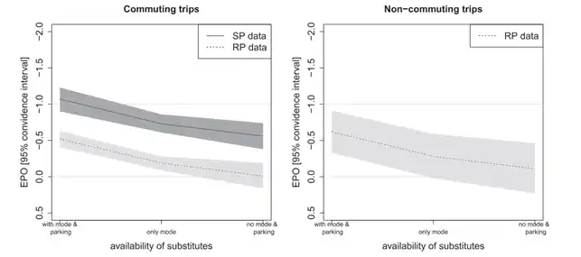

#### 1.3.1.6 Additional comments and conclusions

Of the evidence available, there is a considerable range of results and whether a study was referring to parking demand in a site or area, or to total car travel demand was not always clear. Moreover, it was often unclear whether these estimates were SR or LR, although most appear to be SR.

In relation to Australian evidence, Chambers & Ker (1990) concluded that typical parking price elasticities range from -0.20 to -0.40, which is consistent with the OTPP (SA) estimate of -0.30 (OTTP 1994, cited in Bray (1995)). This compares to substantially lower elasticity estimates by Commeignes (1991) and Shepherd (1972) in their Sydney studies. On the other hand, as shown in the previous section, Hensher & King (2001) estimated higher values for parking in the ‘preferred’ CBD, at around -0.5 or greater. We would not expect NZ elasticities to differ significantly from Australian values for comparable situations.

As noted, most of the evidence available related to SR changes. It is not clear whether longer-run effects will differ substantially from these and, if so, in which direction (larger or smaller).

It would be naive to suggest that any particular parking price elasticity could be used with confidence in analysing parking price policies. The elasticity will depend on the nature and type of parking spaces affected by a particular price change and the opportunities for using alternative parking facilities. These opportunities will differ by time of day and the elasticities themselves would differ for, say, shoppers as opposed to commuters. They would also depend on the physical measures adopted for controlling parking spaces in addition to the price charged.

A useful, high-level, segmentation or the parking market is firstly between CBD and non-CBD areas, and secondly between long-stay parking demand (principally commuters) and shorter-stay demand (principally shopping, personal business etc). For strategic assessment purposes in major Australasian urban centres, we suggest a ‘best estimate’ elasticity of commuter car travel with respect to CBD parking changes of -0.30: this should be applied to that segment of the market affected by such charges. This value is applicable only to CBD trips as parking restraint through pricing is not widely applied elsewhere and there is much less evidence available.

For situations where priced parking is being considered to replace free parking, its meaningless to measure percentage increases from a zero price. For such situations, it is typically found that drive-alone commuting reduces by 10-30%, particularly if implemented with improvements in transit service and rideshare programs and other TDM strategies.

Parking fees affect trip destinations as well as vehicle use. An increase in parking prices can reduce use of parking facilities at a particular location, but this may simply shift vehicle travel to other locations. Increased parking prices may result in spillover parking problems, as motorists find nearby places to park for free illegally. However, if parking prices increase throughout an area, if there is effective enforcement of parking regulations and there are good travel alternatives, parking price increases can reduce total vehicle travel. For some types of trips, pricing can affect parking duration, such as how long shoppers stay at a store.

### 1.3.2 Evidence on parking (price) elasticities cross-modal effects

#### 1.3.2.1 International evidence

Very limited evidence is available internationally on the effect of changes in parking charges on public transport use. This cross-modal effect is best represented in terms of the proportion of people deterred from car usage, by high(er) parking prices and/or limited availability of parking space, who switch to public transport; and this has been reported where possible. However, many studies report cross-elasticity values, so these have also been provided where available. Results were found to be wide-ranging and differed substantially between studies. Key findings included:

- Kocur et al. (1982) conducted a mode choice experiment in 1980 which examined bus demand with respect to parking prices across various US urban centres and found values ranged from 0.13 to 0.19.
- Brown (1972) (cited in various authors estimated a value of 0.30 for Vancouver, from SP studies.
- Commeignes (1991) examined the effects of a $1/day surcharge for AM peak parking in Madison (US) which resulted in a 5% to 8% increase in car commuters switching to bus or park and ride.
- In Europe, Gantvoot (1984) examined the closure of a car park in The Hague town centre and found that 78% of the suppressed car drivers (ie 19%) switched to public transport. This figure translates into an overall shift to public transport of 14% of the previous car park users.
- In Oxford, parking restraint in the CBD resulted in a 10% shift from car to public transport (TRRL, 1980).
- A ‘before and after’ study in Munich-Lebel found that the introduction of residential parking permits resulted in an increase in public transport mode share for employees from 39.7% to 47.3%, ie by some 19% (Topp 1991, cited in Halcrow Fox (1995)).
- An SP study in Bristol (AMPT & Jones, 1992) into the effects of banning cars in the city centre, found that 50% of those affected stated that they would travel by bus all the way, 28% would drive to the bus or train.
- A stated response study in Dublin by Halcrow Fox (1993) found 40% of respondents stated they would change mode following a 40% increase in parking charges, while 68% stated they would change mode following an 80% increase in parking charges.
- Halcrow Fox (1993) suggests that the public transport diversion rate in response to increased parking charges is likely to be as high as 50% to 75%, particularly in central areas where public transport is likely to provide the ‘next best’ alternative.

#### 1.3.2.2 Australasian evidence

Very few studies in Australia and New Zealand have quantified the public transport demand implications of increased parking charges. The available evidence relates primarily to travel to/from CBD destinations, principally by commuters. Generally, the diversion to public transport appears low, although this is difficult to quantify. In Adelaide, for example, Urban Transport Working Group (1995) suggested that a 50% increase in CBD car parking charges could result in a 15% decline in car travel, and that public transport travel could increase 2%.

While not providing any quantified cross-elasticity or diversion rate values, analyses of existing mode choice in Melbourne (based on detailed travel survey data) do provide guidance on how modal choice to different destination categories varies with the availability and pricing of parking spaces. The most relevant findings are summarised as follows:

- Distance of the trip destination from the regional (Melbourne) CBD is the strongest single predictor of mode shares - the greater the distance, the lower the PT mode share.
- Paid parking is effective at restraining private transport mode share (in favour of PT) at university campuses, with a particularly strong effect where high-quality PT services are provided.
- Evidence indicates that charging for parking results in reduced private transport mode shares at larger activity centres.

The most promising destination types for which PT improvements are likely to significantly increase PT mode shares (at the expense of cars) are larger activity centres, universities and other higher education establishments, and job-dense central/inner city areas.[^12]

#### 1.3.2.3 Conclusions

As previously discussed, cross-elasticity estimates are much less transferable between centres than are direct estimates. We therefore would not recommend a specific cross-elasticity value for use in Australasian urban areas. Instead, we have focused on the relevant ‘diversion rates’, ie the proportion of people deterred from car use by increased parking charges who would switch to public transport.

Based on the very limited evidence available, we suggest the following default assumptions be adopted for use in Australasian urban areas on the proportion of travelers deterred from car use by parking charges who would shift to public transport.

- Regional CBD - commuters (peak periods): 75%
- Regional CBD - others (off-peak periods): 50%
- Suburban CBD - commuters (peak periods): 50%
- Other areas - not addressed, but likely to be much lower.

These diversion rates are high relative to those estimated for other travel time/cost components. This is consistent with the affected trips being to/from CBD areas, which have relatively good public transport accessibility.

These rates are essentially SR diversion rates. In the LR, we anticipate that the rates are likely to be somewhat lower as a wider range of alternative responses becomes feasible (eg changing employment location).

[^1]: This section does not cover evidence on own-mode and cross-mode demand elasticity etc for ‘sustainable’ modes (principally walking, cycling, e-bikes, scooters). The evidence base of elasticity-related evidence on this topic is relatively thin; but supplementary research on these market segments may be worthwhile.
[^2]: https://www.atap.gov.au/sites/default/files/documents/m1-public-transport.pdf
[^3]: Cases refer to the number of assessed changes to the frequency of bus services.
[^4]: However, the variability in the data available was such that no firm conclusions could be drawn.
[^5]: If a service was first increased and subsequently decreased back to its original level, with the resultant net patronage change being zero, this would imply that the elasticities (applying the elasticity functions defined in this report) for the service increases and decreases were equal.
[^6]: To calculate a ‘generalised time’ measure, the weighted components can be added as shown in the following equation. All the components are included in the equation, although in practical applications some components may be omitted if they do not change between options.

    *eij = ejj . (Qj/Qi).∂ji*

    where (*Qj/Qi*) represents the relative market shares of the two modes and ∂ji is the relative measure of the demand change in mode *i*

    compared with the demand change in mode j (which is commonly referred to as the diversion factor or diversion rate).
[^9]: The estimated method was inferred when not clearly stated: most models that produce distinct ‘short-run’ and ‘long-run’ estimates are partial adjustment models.
[^10]: They also share other features such as similar technologies in place (ie cameras automatically recognizing car plates). Even though each system sets and applies a charge in a different way, they all share the same aim, which is inducing travel behaviour charge by increasing the car trip cost in comparison with other travel modes. The three schemes show a high deterrent effect of the charge, as measured on travel behaviour changes referred to all traffic and in particular to chargeable traffic. The schemes have been able to reduce negative externalities generated by traffic, such as accidents, congestion and emissions, up to different levels and to generate modal shift towards public transport.
[^11]: https://www.vtpi.org/tdm/tdm41.htm
[^12]: The success of mode shift to PT using paid parking policy varies by types of destinations. Given the regional focus of this report, further discussion of the features of place are beyond the scope.